# Project 2

## Predicting species climate range limits

**Project description:** This project shows how to combine quantile regressions with plant trait data and climate variables to better understand species geographic ranges. Data are from Van Nuland et al. (2020) "Intraspecific trait variation across elevation predicts a widespread tree species' climate niche and range limits" in *Ecology and Evolution*.

Briefly, this study leveraged the natural variation across plant trait measuresments (e.g., leaf area, tree diameter) to predict where climates may be too difficult for a tree species to grow and thrive. The ecological idea behind this project is relatively straightforward: if climate stress leaves a consistent signature on plant trait variation, then trait distributions should be informative for predicting the temperature and precipitation extremes that define species range limits. Here, using quantile regression is helpful because you might expect that a given trait-climate relationship could differ between the upper 95th percentile, median 50th percentile, and lower 5th percentile of the climate gradient. For example, leaf traits might respond differently to temperature extremes at the upper warm edge vs. the lower cold edge of the species climate range, and quantile regressions can be useful for teasing apart these differences.

In the study, I used an approach to sample plant traits across elevation gradients (which act as natural climate gradients) to capture the necessary variation in trait-climate relationships in order to test this idea. See the full project and results from the paper here for more information: https://doi.org/10.1002/ece3.5969.

The following code combines two datasets:

-- A .csv file of plant trait measurements (https://github.com/mvannuland/DataSciPorfolio_datasets)

-- 19 geoTiff files of climate variables (https://www.worldclim.org/data/bioclim.html)

### Contents:

**1 -** Setup

**2 -** Quantile Regressions

**3 -** Multivariate analysis

**4 -** Mapping climate constraints

### 1. Setup

Load the relevant R libraries, plant data, and climate data.

```r
library(ggpubr)
```

### 2. Quantile Regressions with Temperature and Precipitation

The following code models the 5th, 50th, and 95th quantile regressions for each trait-temperature and trait-precipitation relationship. In particular, the lower and upper quantiles show where the extent of plant trait variation predicts the species' climate range limits. White areas beyond the outermost regression lines indicate "No-go zones" where there are no plant trait-climate combinations that likely limit the tree species from persisting under those conditions.

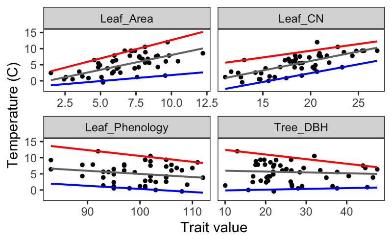

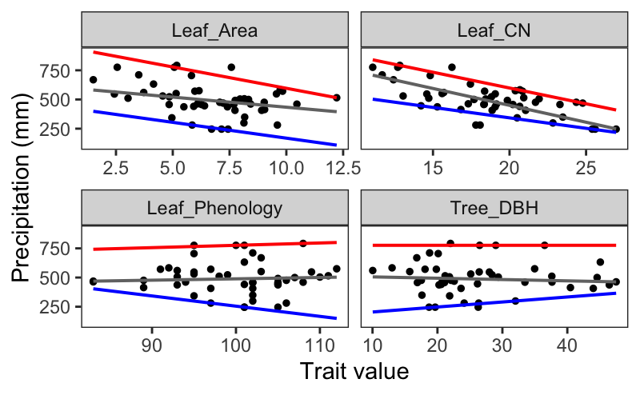

### 3. Multivariate analysis of climate variables

Plants respond to more than just temperature and precipitation. Here, I show an example of how to use Principle Component Analysis to summarize the complex climate environment (i.e., combining dimensionality from all 19 climate variables) and model the subsequent plant trait-climate relationships using the new multivariate climate axes.

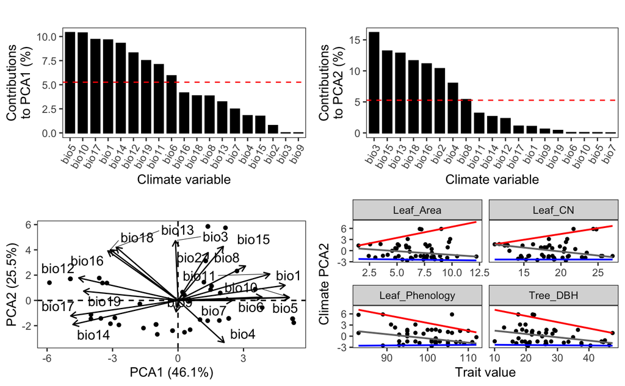

### 4. Mapping climate constraints on plant trait variation

In sections 2 and 3 I showed how variation in plant traits can predict the climatic limits a species can tolerate. Now, we can reverse this by applying the quantial regression equations to spatial layers of climate data. This approach generates maps that show how the extent of plant trait variation differs across the landscape. Specifically, the color gradients shows changes in projected trait diversity - darker areas are climates that can contain a broad range of plant trait values (high functional diversity), whereas lighter areas are climates that can only support a limited range of trait values (low functional diversity).

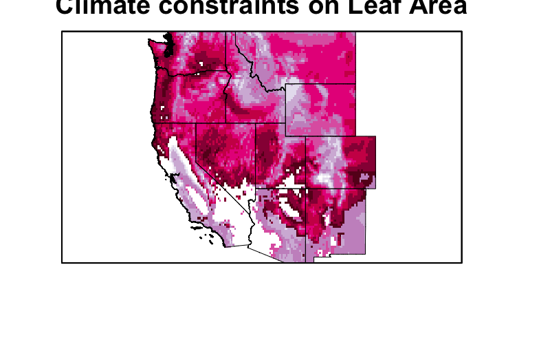

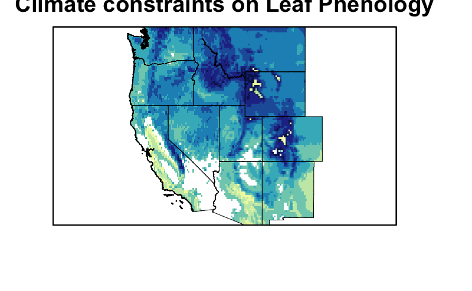

```r
plot(LeafArea.stack.max, col=LeafArea.pal, xaxt="n", yaxt="n", legend=F, main='Climate constraints on Leaf Area')
plot(state.sub, add = TRUE, lwd=0.5, xaxt="n", yaxt="n")
plot(LeafPhenology.stack.max, col=Phenology.pal, xaxt="n", yaxt="n", legend=F, main='Climate constraints on Leaf Phenology')

plot(state.sub, add = TRUE, lwd=0.5, xaxt="n", yaxt="n")
```